# Covid Multi-State Data Analysis

### Goal

The purpose of this notebook is to show the analysis of Covid data using data from all of the states

Author: John Pratt Data Updated: 7/17/2020

Data can be found here:

https://covidtracking.com/data

### Methodology

The CDC has released the IFR (Infection fatality rate) of 0.26%

Reference: https://reason.com/2020/06/28/cdc-antibody-studies-confirm-huge-gap-between-covid-19-infections-and-known-cases/

Using this we can calculate the number of people who have actually had Covid because we know the number of deaths.

(number of individuals who have had covid) = total deaths / .0026

We can calculate the percentage immune by dividing the (number of individuals who have had it) / (total population)

### Preparing the data

First we need to prepare the data and read it in from a CSV as a dataframe in R.

```r
rawData <- read.csv("daily.csv", stringsAsFactors = FALSE)

rawData$date <- as.character(rawData$date)
# Fix the date field
rawData$FixedDate <- as.Date(rawData$date, format = "%Y%m%d")

# We also need to read in the data for the US
dataUS <- read.csv("daily-us.csv", stringsAsFactors = FALSE)

dataUS$date <- as.character(dataUS$date)
# Fix the date field
dataUS$FixedDate <- as.Date(dataUS$date, format = "%Y%m%d")
```

Now we build a dataframe for just the states we are interested in.

```r
dataVirginia     <- subset(rawData,
                         rawData$'state' == "VA")
dataFlorida      <- subset(rawData,
                         rawData$'state' == "FL")
dataNewYork      <- subset(rawData,
                         rawData$'state' == "NY")
dataCali         <- subset(rawData,
                         rawData$'state' == "CA")
dataWashington   <- subset(rawData,
                         rawData$'state' == "WA")
dataNewJersey    <- subset(rawData,
                         rawData$'state' == "NJ")
dataConnecticut  <- subset(rawData,
                         rawData$'state' == "CO")
dataMass         <- subset(rawData,
                         rawData$'state' == "MA")
dataTexas        <- subset(rawData,
                         rawData$'state' == "TX")
dataArizona      <- subset(rawData,
                         rawData$'state' == "AZ")
```

### Calculating the Totals for the State

In order to get an idea of overall statistics for the state we will total the numbers in the raw data set.

```r
VAtotalCases            = head(dataVirginia$positive,1)
VAtotalHospitalizations = head(dataVirginia$hospitalizedCumulative,1)
VAtotalDeaths           = head(dataVirginia$death,1)
FLtotalCases            = head(dataFlorida$positive,1)
FLtotalHospitalizations = head(dataFlorida$hospitalizedCumulative,1)
FLtotalDeaths           = head(dataFlorida$death,1)
NYtotalCases            = head(dataNewYork$positive,1)
NYtotalHospitalizations = head(dataNewYork$hospitalizedCumulative,1)
NYtotalDeaths           = head(dataNewYork$death,1)
```

*Totals for the States:*

#### Virginia

- Cases: 74431
- Hospitalizations: 10778
- Deaths: 2007

#### Florida

- Cases: 315775
- Hospitalizations: 20154
- Deaths: 4782

#### New York

- Cases: 404775
- Hospitalizations: 89995
- Deaths: 25014

### Calculate heard immunity rate of a subset of states

The CDC has released the infection fatility rate (IFR) as 0.26%. Using the total number of deaths in specific states, we can calculate the total number of people who have had COVID in this region.

```r
VAnumberHadit = VAtotalDeaths / .0026
FLnumberHadit  = FLtotalDeaths / .0026
NYnumberHadit  = NYtotalDeaths / .0026
```

Individuals who have had Covid:

- Virginia: 771923.1
- Florida: 1839231
- New York: 9620769

Using the number of individuals who have had COVID divided by the total population of the states, we can calculate the heard immunity threshold of the region.

Total Population in 2020:

- VA: 8,536,000
- FL: 21,480,000
- NY: 19,450,000

*Percentage of individuals who have had Covid:*

- Virginia: 9.0431476%
- Florida: 8.5625269%
- New York: 49.4641092%

### Total Cases Over Time

Some additional data gleaned from the data set:

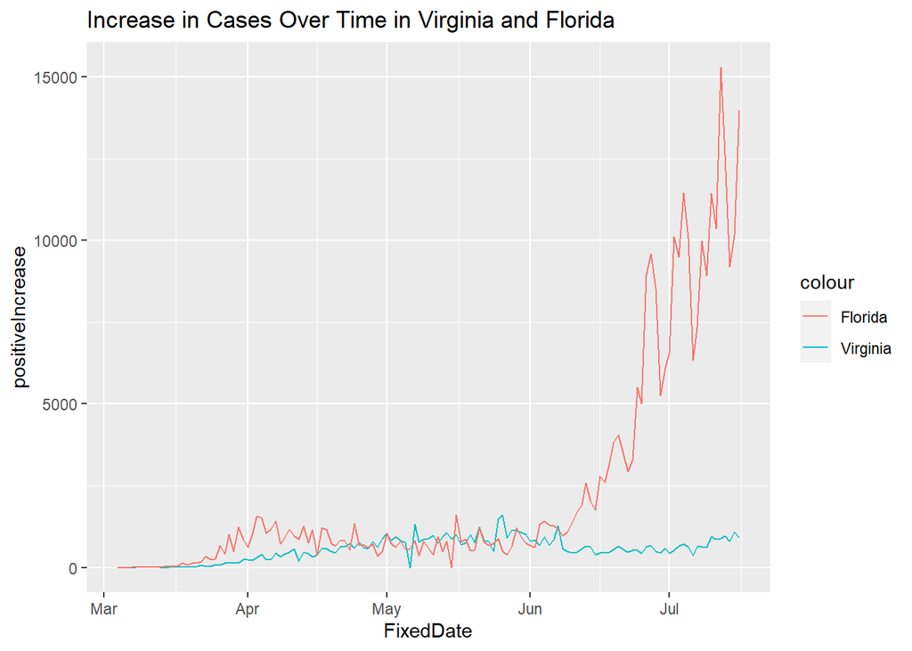

```r
totalCases_vs_Deaths_Plot = ggplot() +
  geom_line(data = dataVirginia,
            aes(x = FixedDate, y = positiveIncrease, color='Virginia')) +
  geom_line(data = dataFlorida,
            aes(x = FixedDate, y = positiveIncrease, color='Florida'))
print(totalCases_vs_Deaths_Plot +
        ggtitle("Increase in Cases Over Time in Virginia and Florida"))
```

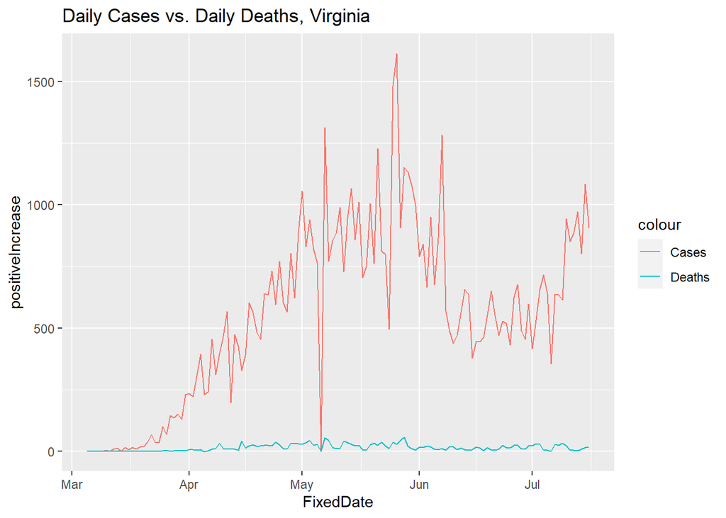

```r
totalCases_Eastern_Plot <- ggplot() +
  geom_line(data = dataVirginia,
            aes(x = FixedDate, y = positiveIncrease, color='Cases')) +
  geom_line(data = dataVirginia,
            aes(x = FixedDate, y = deathIncrease, color = 'Deaths'))
print(totalCases_Eastern_Plot +
        ggtitle("Daily Cases vs. Daily Deaths, Virginia"))
```

We can also separate out the graph of deaths related to COVID to more closely examine the trend. Although the number of cases is rising, the number of deaths is not.

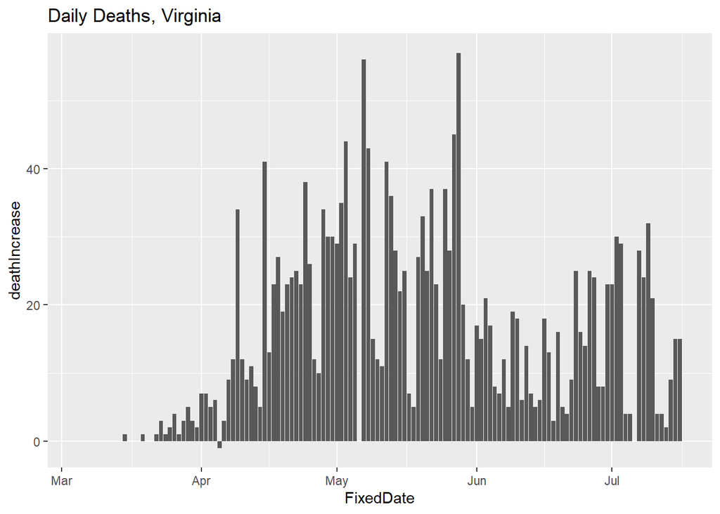

```r
totalDeaths_Eastern_Plot =
  ggplot(data = dataVirginia, aes(x = FixedDate, y=deathIncrease)) +
  geom_bar(stat="identity")
print(totalDeaths_Eastern_Plot +
        ggtitle("Daily Deaths, Virginia"))
```

### Some additional plots for comparison

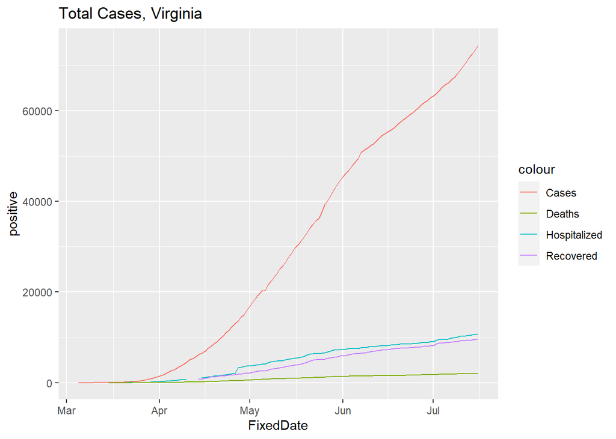

```r
totalCases_Central_Plot = ggplot() +
  geom_line(data = dataVirginia,
            aes(x = FixedDate, y = positive, color = "Cases")) +
  geom_line(data = dataVirginia,
            aes(x = FixedDate, y = hospitalizedCumulative, color = "Hospitalized")) +
  geom_line(data = dataVirginia,
            aes(x = FixedDate, y = recovered, color = "Recovered")) +
  geom_line(data = dataVirginia,
            aes(x = FixedDate, y = death, color = "Deaths"))


print(totalCases_Central_Plot +
        ggtitle("Total Cases, Virginia"))
```

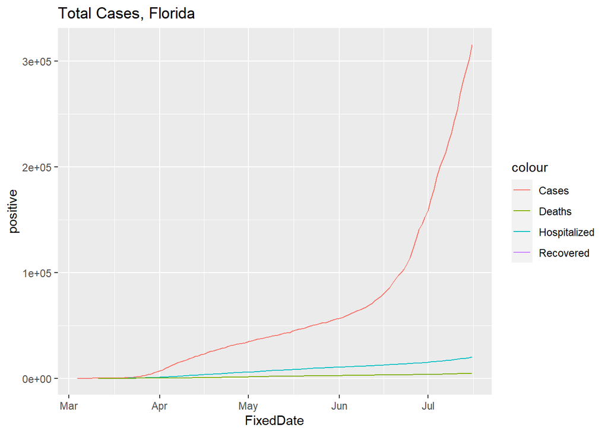

```r
totalCases_Central_Plot = ggplot() +
  geom_line(data = dataFlorida,
            aes(x = FixedDate, y = positive, color = "Cases")) +
  geom_line(data = dataFlorida,
            aes(x = FixedDate, y = hospitalizedCumulative, color = "Hospitalized")) +
  geom_line(data = dataFlorida,
            aes(x = FixedDate, y = recovered, color = "Recovered")) +
  geom_line(data = dataFlorida,
            aes(x = FixedDate, y = death, color = "Deaths"))


print(totalCases_Central_Plot +
        ggtitle("Total Cases, Florida"))
```

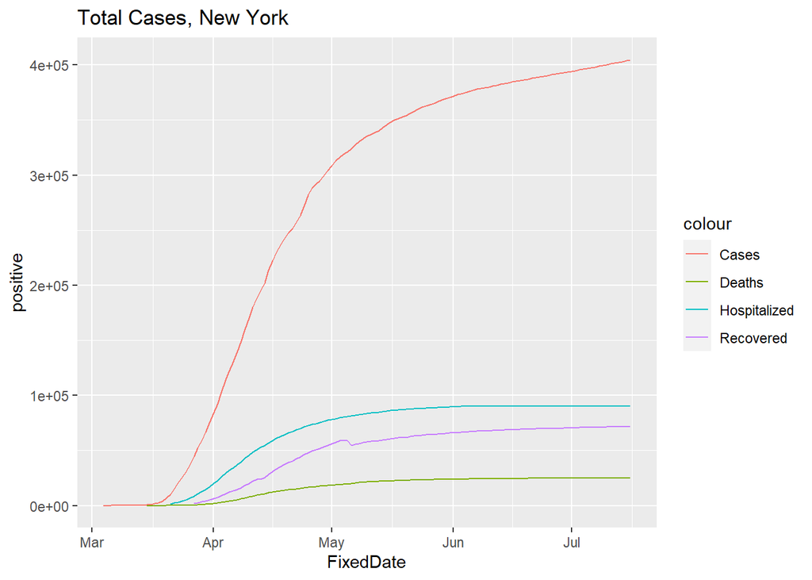

```r
totalCases_Central_Plot = ggplot() +
  geom_line(data = dataNewYork,
            aes(x = FixedDate, y = positive, color = "Cases")) +
  geom_line(data = dataNewYork,
            aes(x = FixedDate, y = hospitalizedCumulative, color = "Hospitalized")) +
  geom_line(data = dataNewYork,
            aes(x = FixedDate, y = recovered, color = "Recovered")) +
  geom_line(data = dataNewYork,
            aes(x = FixedDate, y = death, color = "Deaths"))


print(totalCases_Central_Plot +
        ggtitle("Total Cases, New York"))
```

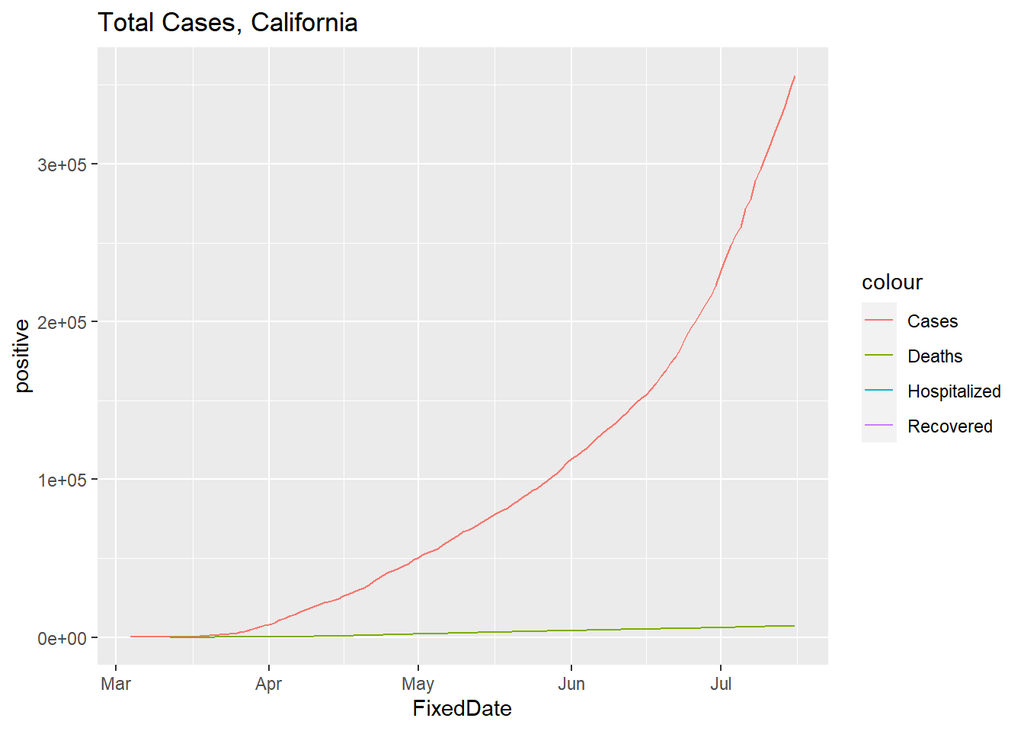

```r
totalCases_Central_Plot = ggplot() +
  geom_line(data = dataCali,
            aes(x = FixedDate, y = positive, color = "Cases")) +
  geom_line(data = dataCali,
            aes(x = FixedDate, y = hospitalizedCumulative, color = "Hospitalized")) +
  geom_line(data = dataCali,
            aes(x = FixedDate, y = recovered, color = "Recovered")) +
  geom_line(data = dataCali,
            aes(x = FixedDate, y = death, color = "Deaths"))


print(totalCases_Central_Plot +
        ggtitle("Total Cases, California"))
```

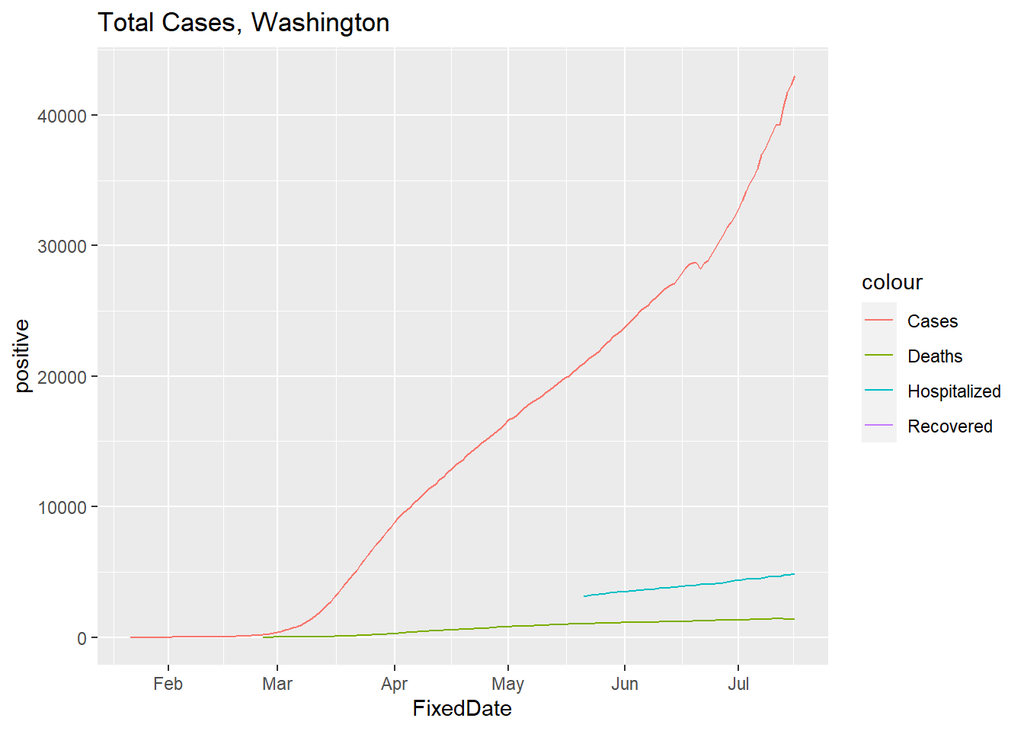

```r
totalCases_Central_Plot = ggplot() +
  geom_line(data = dataWashington,
            aes(x = FixedDate, y = positive, color = "Cases")) +
  geom_line(data = dataWashington,
            aes(x = FixedDate, y = hospitalizedCumulative, color = "Hospitalized")) +
  geom_line(data = dataWashington,
            aes(x = FixedDate, y = recovered, color = "Recovered")) +
  geom_line(data = dataWashington,
            aes(x = FixedDate, y = death, color = "Deaths"))


print(totalCases_Central_Plot +
        ggtitle("Total Cases, Washington"))
```

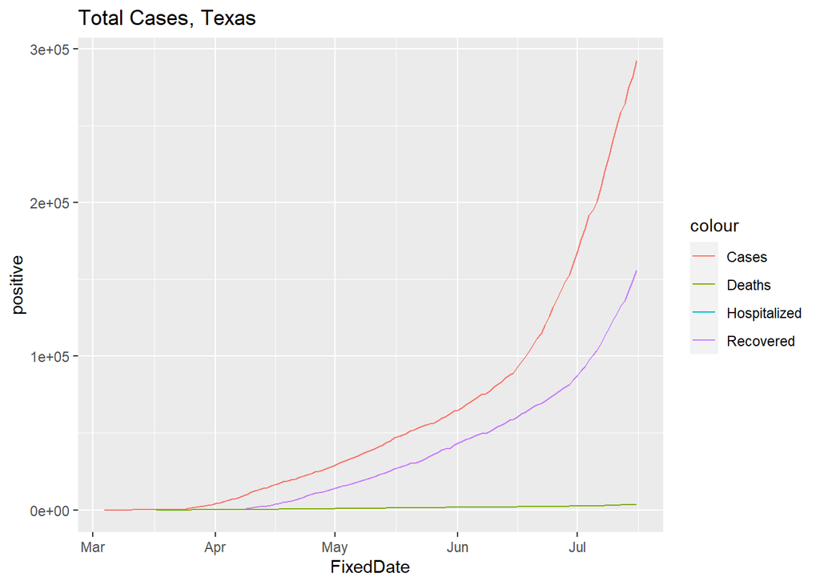

```r
totalCases_Central_Plot = ggplot() +
  geom_line(data = dataTexas,
            aes(x = FixedDate, y = positive, color = "Cases")) +
  geom_line(data = dataTexas,
            aes(x = FixedDate, y = hospitalizedCumulative, color = "Hospitalized")) +
  geom_line(data = dataTexas,
            aes(x = FixedDate, y = recovered, color = "Recovered")) +
  geom_line(data = dataTexas,
            aes(x = FixedDate, y = death, color = "Deaths"))


print(totalCases_Central_Plot +
        ggtitle("Total Cases, Texas"))
```

### Analysis

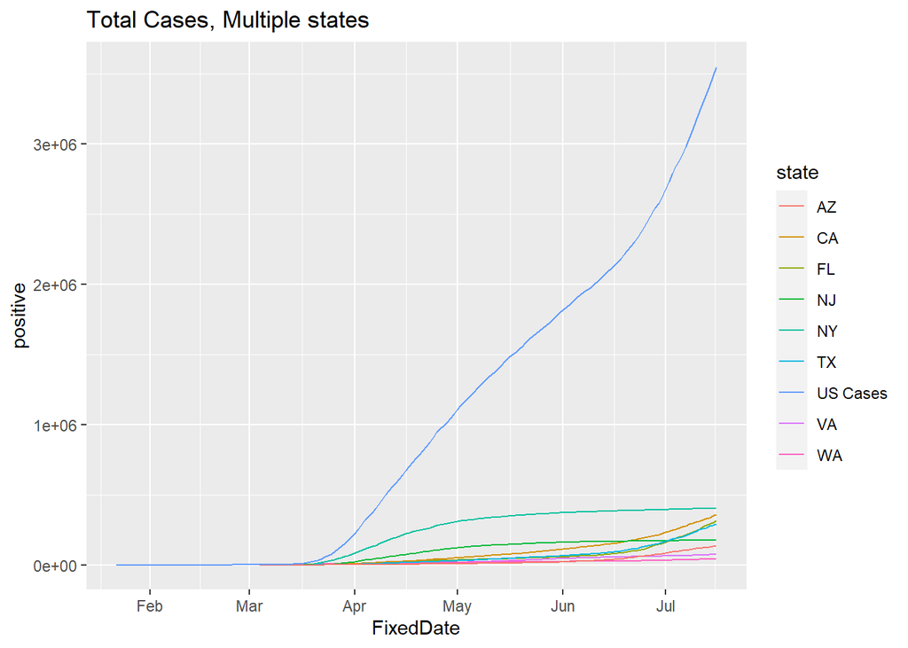

```r
totalCases_Central_Plot = ggplot() +
  geom_line(data = dataVirginia,
            aes(x = FixedDate, y = positive, color = state)) +
  geom_line(data = dataNewYork,
            aes(x = FixedDate, y = positive, color = state)) +
  geom_line(data = dataFlorida,
            aes(x = FixedDate, y = positive, color = state)) +
  geom_line(data = dataWashington,
            aes(x = FixedDate, y = positive, color = state)) +
  geom_line(data = dataCali,
            aes(x = FixedDate, y = positive, color = state)) +
  geom_line(data = dataNewJersey,
            aes(x = FixedDate, y = positive, color = state)) +
  geom_line(data = dataTexas,
            aes(x = FixedDate, y = positive, color = state)) +
  geom_line(data = dataArizona,
            aes(x = FixedDate, y = positive, color = state)) +
  geom_line(data = dataUS,
            aes(x = FixedDate, y = positive, color = "US Cases"))


print(totalCases_Central_Plot +
        ggtitle("Total Cases, Multiple states"))
```

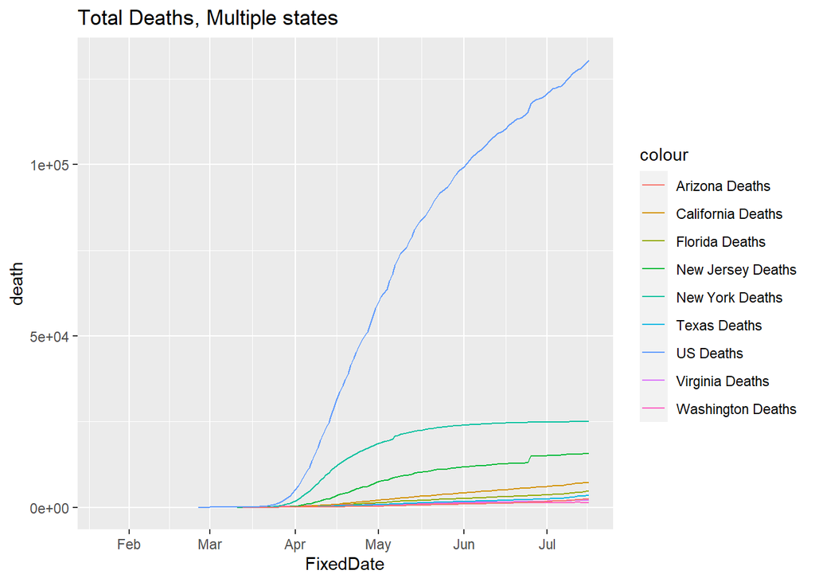

```r
totalCases_Central_Plot = ggplot() +
  geom_line(data = dataVirginia,
            aes(x = FixedDate, y = death, color = "Virginia Deaths")) +
  geom_line(data = dataNewYork,
            aes(x = FixedDate, y = death, color = "New York Deaths")) +
  geom_line(data = dataFlorida,
            aes(x = FixedDate, y = death, color = "Florida Deaths")) +
  geom_line(data = dataWashington,
            aes(x = FixedDate, y = death, color = "Washington Deaths")) +
  geom_line(data = dataCali,
            aes(x = FixedDate, y = death, color = "California Deaths")) +
  geom_line(data = dataNewJersey,
            aes(x = FixedDate, y = death, color = "New Jersey Deaths")) +
  geom_line(data = dataTexas,
            aes(x = FixedDate, y = death, color = "Texas Deaths")) +
  geom_line(data = dataArizona,
            aes(x = FixedDate, y = death, color = "Arizona Deaths")) +
  geom_line(data = dataUS,
            aes(x = FixedDate, y = death, color = "US Deaths"))


print(totalCases_Central_Plot +
        ggtitle("Total Deaths, Multiple states"))
```

#

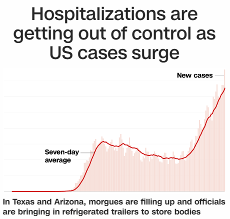